# lab2_nikolaev_var_5

### РОССИЙСКИЙ УНИВЕРСИТЕТ ДРУЖБЫ НАРОДОВ

#### Факультет физико-математических и естественных наук

#### Кафедра информационных технологий

## ОТЧЕТ ПО ЛАБОРАТОРНОЙ РАБОТЕ №2

#### Дисциплина: Интеллектуальный анализ данных

##### Студент: Николаев Александр Викторович

##### Группа: НФИбд-01-17

## Москва 2020

### Вариант №5

```python
import numpy as np
import pandas as pd
import matplotlib.pyplot as plt
%matplotlib inline
import seaborn as sns
```

1. Используя функционал библиотеки Pandas, считаем заданный набор данных из репозитария UCI.

https://archive.ics.uci.edu/ml/machine-learning-databases/credit-screening/crx.data

```python
data = pd.read_csv('https://archive.ics.uci.edu/ml/machine-learning-databases/credit-screening/crx.data',
                   header=None, prefix='A')
```

1. Проведем исследование набора данных

```python
data.head()
```

|  | A0 | A1 | A2 | A3 | A4 | A5 | A6 | A7 | A8 | A9 | A10 | A11 | A12 | A13 | A14 | A15 |
| --- | --- | --- | --- | --- | --- | --- | --- | --- | --- | --- | --- | --- | --- | --- | --- | --- |
| 0 | b | 30.83 | 0.000 | u | g | w | v | 1.25 | t | t | 1 | f | g | 00202 | 0 | + |
| 1 | a | 58.67 | 4.460 | u | g | q | h | 3.04 | t | t | 6 | f | g | 00043 | 560 | + |
| 2 | a | 24.50 | 0.500 | u | g | q | h | 1.50 | t | f | 0 | f | g | 00280 | 824 | + |
| 3 | b | 27.83 | 1.540 | u | g | w | v | 3.75 | t | t | 5 | t | g | 00100 | 3 | + |
| 4 | b | 20.17 | 5.625 | u | g | w | v | 1.71 | t | f | 0 | f | s | 00120 | 0 | + |

Числовые признаки: `A1`, `A2`, `A7`, `A10`, `A13`, `A14`

Категориальные признаки: `A0`, `A3`, `A4`, `A5`, `A6`, `A8`, `A9`, `A11`, `A12`

Таргет: `A15`

```python
num_feats = ['A1', 'A2', 'A7', 'A10', 'A13', 'A14']
cat_feats = ['A0', 'A3', 'A4', 'A5', 'A6', 'A8', 'A9', 'A11', 'A12']
target = 'A15'
```

Заполним пропуски ('?') в числовых признаках медианным значением, а в категориальных - модой.

```python
for feat in num_feats:
    data[feat] = data[feat].replace('?', np.nan).astype(float)
```

```python
data.replace('?', np.nan, inplace=True)

print(f'Количество пропусков до заполнения: {data.isna().sum().sum()}')

data[num_feats] = data[num_feats].fillna(data[num_feats].median())
data[cat_feats] = data[cat_feats].fillna(data[cat_feats].mode().squeeze())

print(f'Количество пропусков после заполнения: {data.isna().sum().sum()}')
```

```
Количество пропусков до заполнения: 67
Количество пропусков после заполнения: 0
```

1. Определим признак, содержащий метку класса. Если признак, содержащий метку класса, принимает более 10 различных значений, то выполним дискретизацию этого признака, перейдя к 3-4 диапазонам значений.

Метку содержит признак `A15`

Переименуем его в target

```python
data.rename(columns={'A15': 'target'}, inplace=True)
# data['target'].replace({'-': -1, '+': 1}, inplace=True)
print(data['target'].value_counts())
```

```
-    383
+    307
Name: target, dtype: int64
```

Поскольку целевой признак имеет всего две метки класса, то дискретизация не требуется.

1. Определим числовой признак, имеющий максимальную дисперсию. Исследуем, принимает ли это признак дискретные или непрерывные значения.

```python
max_var_feat = num_feats[data[num_feats].var().argmax()]
print(f'Числовой признак с наибольшей дисперсией: {max_var_feat}, дисперсия = {data[num_feats].var().max()}')
```

```
Числовой признак с наибольшей дисперсией: A14, дисперсия = 27145169.084840517
```

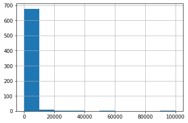

```python
data[max_var_feat].hist();
```

```python
data[max_var_feat].value_counts()
```

```
0.0        295
1.0         29
500.0       10
1000.0      10
2.0          9
          ...
1349.0       1
2206.0       1
51100.0      1
4071.0       1
10000.0      1
Name: A14, Length: 240, dtype: int64
```

Можно сказать, что признак принимает дискретные значения, т.к.: 1) нет действительных значений; 2) уникальных значение всего 240, что сильно меньше размера датасета; 3) Гистограмма признака показывает не непрерывное распределение

1. При помощи класса SelectKBest библиотеки scikit-learn найдём два признака, имеющих наиболее выраженную взаимосвязь с признаком, имеющим максимальную дисперсию.

Добавим в исследование категории, предварительно закодировав их с помощью LabelEncoding

```python
for feat in cat_feats:
    data[feat] = data[feat].astype('category').cat.codes
```

```python
from sklearn.feature_selection import SelectKBest, f_regression

X = data[num_feats].drop(columns=max_var_feat)
y = data[max_var_feat]

k_best = SelectKBest(score_func=f_regression, k=2)
fit = k_best.fit(X, y)

print("\nОценки признаков:\n")
for col, score in zip(X.columns, fit.scores_):
    print(f'{col} : {score}')


cols = k_best.get_support(indices=True)
print("\nОтобранные признаки:\n", X.iloc[:, cols].head())
```

```
Оценки признаков:

A1 : 0.2411530061137094
A2 : 10.5897958111878
A7 : 1.8185699022332564
A10 : 2.80239661507955
A13 : 2.905348612910606

Отобранные признаки:
       A2    A13
0  0.000  202.0
1  4.460   43.0
2  0.500  280.0
3  1.540  100.0
4  5.625  120.0
```

1. Визуализируем набор данных в виде точек плоскости с координатами, соответствующими найденным признакам, отображая точки различных классов разными цветами. Подпишим оси и рисунок, создадим легенду набора данных.

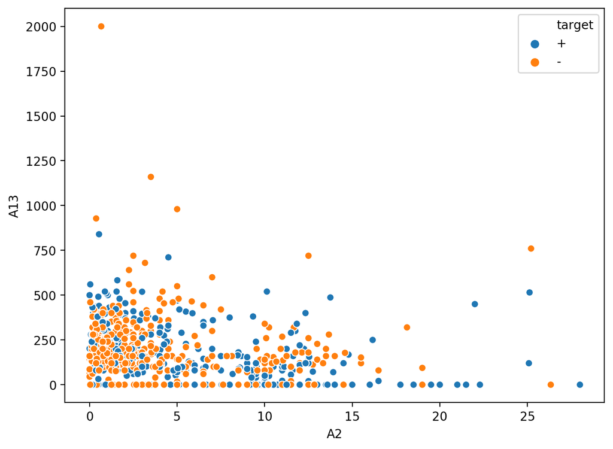

```python
plt.figure( figsize=(8, 6), dpi=200 )
sns.scatterplot(x=data['A2'], y=data['A13'], hue=data['target']);
```

1. Оставляя в наборе данных только числовые признаки, найдём и выведем на экран размерность метода главных компонент (параметр n_components), для которой доля объясняемой дисперсии будет не менее 99%.

```python
from sklearn.decomposition import PCA
```

```python
X = data[num_feats]

for r in range(1, len(num_feats)+1):
    pca = PCA(n_components=r)
    pca.fit(X)
    print(f"r = {r}\tДисперсия = {sum(pca.explained_variance_ratio_)*100}%")
```

```
r = 1	Дисперсия = 99.89061858357638%
r = 2	Дисперсия = 99.99927484289051%
r = 3	Дисперсия = 99.99980306568906%
r = 4	Дисперсия = 99.9999063932179%
r = 5	Дисперсия = 99.9999706486177%
r = 6	Дисперсия = 99.99999999999997%
```

Для любого количества компонент, доля объясняемой дисперсии будет не менее 99%

1. Пользуясь методом главных компонент, снизим размерность набора данных до двух признаков и изобразим полученный набор данных в виде точек на плоскости, отображая точки различных классов разными цветами. Подпишим оси и рисунок, создадим легенду набора данных.

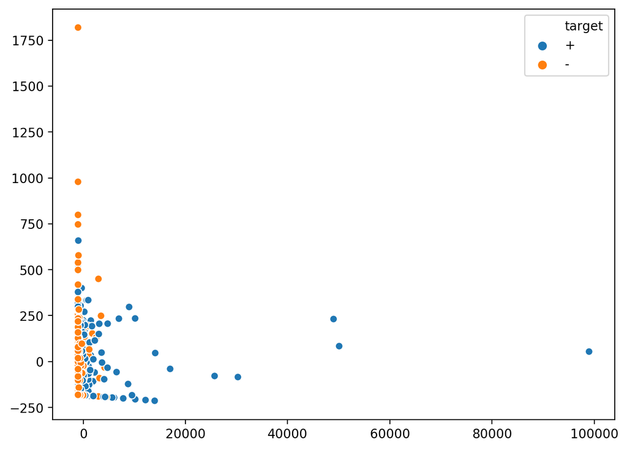

```python
pca = PCA(n_components=2)
pcad = pca.fit_transform(X)

plt.figure(figsize=(8, 6), dpi=200)
sns.scatterplot(x=pcad[:, 0], y=pcad[:, 1], hue=data['target']);
```